# SupplyChain

```python
import pandas as pd
import numpy as np
import matplotlib.pyplot as plt
import sklearn.metrics as metrics
from sklearn.metrics import mean_squared_error
from sklearn.metrics import mean_absolute_error
from statsmodels.tsa.api import ExponentialSmoothing, SimpleExpSmoothing, Holt
%matplotlib inline
from math import sqrt
```

```python
# Import data
df = pd.read_csv("C:/SEM 4/DAB 400 (Supply chain)/Final Presentation/DatasetsCaseAssignment/example_retail_sales.csv", index_col ='ds', parse_dates =True)
```

```python
df.rename(columns={'pounds_per_cow': 'y'}, inplace=True)
```

```python
df.head()
```

| ds | y |
| --- | --- |
| 1992-01-01 | 146376 |
| 1992-02-01 | 147079 |
| 1992-03-01 | 159336 |
| 1992-04-01 | 163669 |
| 1992-05-01 | 170068 |

### Moving Average

```python
# the simple moving average over a period of 10
df['SMA_5'] = df.y.rolling(5, min_periods=1).mean()
```

```python
# the simple moving average over a period of 10
df['SMA_10'] = df.y.rolling(10, min_periods=1).mean()
```

```python
df.head()
```

| ds | y | SMA_5 | SMA_10 |
| --- | --- | --- | --- |
| 1992-01-01 | 146376 | 146376.000000 | 146376.000000 |
| 1992-02-01 | 147079 | 146727.500000 | 146727.500000 |
| 1992-03-01 | 159336 | 150930.333333 | 150930.333333 |
| 1992-04-01 | 163669 | 154115.000000 | 154115.000000 |
| 1992-05-01 | 170068 | 157305.600000 | 157305.600000 |

```python
# the simple moving average over a period of 10
df['SMA_20'] = df.y.rolling(20, min_periods=1).mean()
```

```python
df.head()
```

| ds | y | SMA_5 | SMA_10 | SMA_20 |
| --- | --- | --- | --- | --- |
| 1992-01-01 | 146376 | 146376.000000 | 146376.000000 | 146376.000000 |
| 1992-02-01 | 147079 | 146727.500000 | 146727.500000 | 146727.500000 |
| 1992-03-01 | 159336 | 150930.333333 | 150930.333333 | 150930.333333 |
| 1992-04-01 | 163669 | 154115.000000 | 154115.000000 | 154115.000000 |
| 1992-05-01 | 170068 | 157305.600000 | 157305.600000 | 157305.600000 |

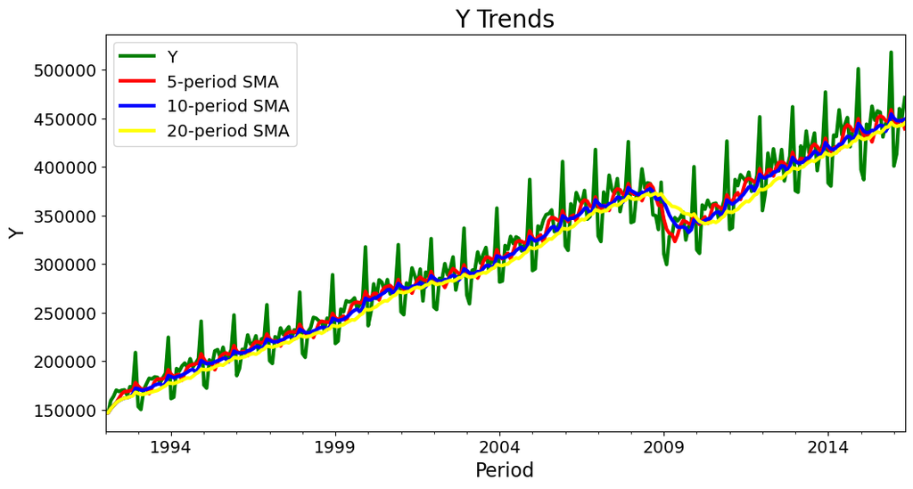

```python
# colors for the line plot
colors = ['green', 'red', 'blue', 'yellow']


# line plot for demand
df.plot(color=colors, linewidth=3, figsize=(12,6))

# modify ticks size
plt.xticks(fontsize=14)
plt.yticks(fontsize=14)
plt.legend(labels =['Y', '5-period SMA', '10-period SMA', '20-period SMA'], fontsize=14)

# title and labels
plt.title('Y Trends', fontsize=20)
plt.xlabel('Period', fontsize=16)
plt.ylabel('Y', fontsize=16)
```

```python
df['Error_10']=df['y']-df['SMA_10']
```

```python
# For KPI Calculation
Bias = df["Error_10"].mean()
print("Bias:",round(Bias,2))
MAE = df["Error_10"].abs().mean()
print("MAE:",round(MAE,2))
RMSE = np.sqrt((df["Error_10"]**2).mean())
print("RMSE:",round(RMSE,2))
MSE= (df["Error_10"]**2).mean()
print("MSE:",round(MSE,2))

MAPE=np.mean(np.abs(df["Error_10"]/df["y"])*100)
print("MAPE:",round(MAPE,2))
```

```
Bias: 4580.29
MAE: 16186.34
RMSE: 21276.45
MSE: 452687525.06
MAPE: 5.31
```

```python
mae = metrics.mean_absolute_error(df['y'], df['SMA_10'])
mse = metrics.mean_squared_error(df['y'], df['SMA_10'])
rmse = np.sqrt(mse) # or mse**(0.5)
```

```python
print(round(mae,2))
print(round(mse,2))
print(round(rmse,2))
```

```
16186.34
452687525.06
21276.45
```

```
Retail sale
```

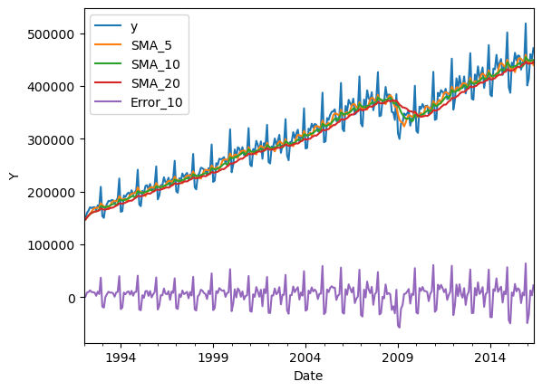

```python
ax = df.plot()
ax.set_xlabel("Date")
ax.set_ylabel("Y")
print("Retail sale")
```

### Linear Regression

```python
import pandas as pd
import numpy as np
from sklearn.linear_model import LinearRegression
from sklearn.metrics import mean_squared_error, r2_score
from datetime import datetime
```

```python
# Import data
df = pd.read_csv("C:/SEM 4/DAB 400 (Supply chain)/Final Presentation/DatasetsCaseAssignment/example_retail_sales.csv")
```

```python
df.head()
```

|  | ds | y |
| --- | --- | --- |
| 0 | 1992-01-01 | 146376 |
| 1 | 1992-02-01 | 147079 |
| 2 | 1992-03-01 | 159336 |
| 3 | 1992-04-01 | 163669 |
| 4 | 1992-05-01 | 170068 |

```python
# Convert the date string to a numerical format
df['ds'] = df['ds'].apply(lambda x: (datetime.strptime(x, '%Y-%m-%d') - datetime(1970,1,1)).days)

X = df['ds'].values.reshape(-1, 1)
y = df['y'].values.reshape(-1, 1)

reg = LinearRegression()
reg.fit(X, y)

print('Slope: ', reg.coef_[0][0])
print('Intercept: ', reg.intercept_[0])

y_pred = reg.predict(X)

mse = mean_squared_error(y, y_pred)
r2 = r2_score(y, y_pred)
print('Mean squared error: ', mse)
print('R-squared: ', r2)
```

```
Slope:  31.999630596773375
Intercept:  -90337.77263485454
Mean squared error:  598724374.5126303
R-squared:  0.9189293673569046
```

The value of R-squared ranges from 0 to 1, where 0 indicates that the model explains none of the variability of the response data around its mean, and 1 indicates that the model explains all of the variability of the response data around its mean. Therefore, an R-squared value of 0.9189 suggests that 91.89% of the variance in the dependent variable can be explained by the independent variable(s) in the model, which indicates a strong fit between the model and the data.

### Creating ARIMA model

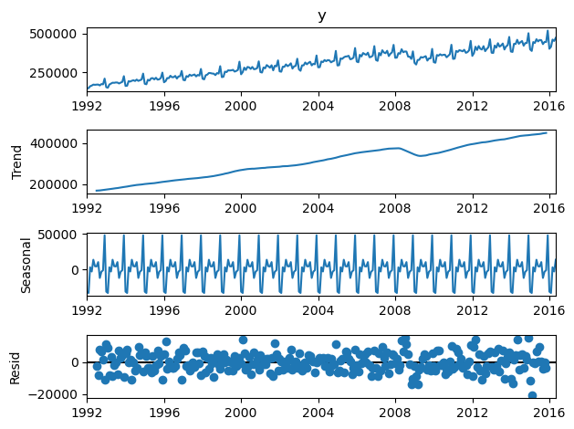

```python
# Import seasonal decompose
from statsmodels.tsa.seasonal import seasonal_decompose

# Perform additive decomposition
decomp = seasonal_decompose(df['y'])


# Plot decomposition
decomp.plot()
plt.show()
```

```python
# Importing the ARMA model
from statsmodels.tsa.arima.model import ARIMA

# Instantiate the model
__model_ARIMA = ARIMA(df['y'], order=(2,1,2))

# Fit the model
__results_M_ARIMA = __model_ARIMA.fit()



# Print model fit summary
print(__results_M_ARIMA.summary())
```

```
                               SARIMAX Results
==============================================================================
Dep. Variable:                      y   No. Observations:                  293
Model:                 ARIMA(2, 1, 2)   Log Likelihood               -3360.130
Date:                Sun, 16 Apr 2023   AIC                           6730.260
Time:                        16:44:19   BIC                           6748.644
Sample:                    01-01-1992   HQIC                          6737.624
                         - 05-01-2016
Covariance Type:                  opg
==============================================================================
                 coef    std err          z      P>|z|      [0.025      0.975]
------------------------------------------------------------------------------
ar.L1          0.4293      0.129      3.335      0.001       0.177       0.682
ar.L2         -0.2868      0.062     -4.623      0.000      -0.408      -0.165
ma.L1         -1.2928      0.134     -9.676      0.000      -1.555      -1.031
ma.L2          0.4957      0.107      4.629      0.000       0.286       0.706
sigma2      5.412e+08   1.98e-10   2.73e+18      0.000    5.41e+08    5.41e+08
===================================================================================
Ljung-Box (L1) (Q):                   0.06   Jarque-Bera (JB):                 3.36
Prob(Q):                              0.80   Prob(JB):                         0.19
Heteroskedasticity (H):               1.58   Skew:                             0.15
Prob(H) (two-sided):                  0.03   Kurtosis:                         3.43
===================================================================================

Warnings:
[1] Covariance matrix calculated using the outer product of gradients (complex-step).
[2] Covariance matrix is singular or near-singular, with condition number 5.98e+33. Standard errors may be unstable.
```